# Ninjacart: CV Classification

## Problem Statement

Ninjacart is India's largest fresh produce supply chain company. They are pioneers in solving one of the toughest supply chain problems of the world by leveraging innovative technology. They source fresh produce from farmers and deliver them to businesses within 12 hours. An integral component of their automation process is the development of robust classifiers which can distinguish between images of different types of vegetables, while also correctly labeling images that do not contain any one type of vegetable as noise.

As a starting point, ninjacart has provided us with a dataset scraped from the web which contains train and test folders, each having 4 sub-folders with images of onions, potatoes, tomatoes and some market scenes. We have been tasked with preparing a multiclass classifier for identifying these vegetables. The dataset provided has all the required images to achieve the task.

**DataSet**

The dataset contains images of the following food items: noise-Indian market and images of vegetables- onion, potato and tomato.

**Data Collection**

The images in this dataset were scraped from Google.

**Content**

This dataset contains a folder train, which has a total of 3135 images, split into four folders as follows:

- Tomato : 789
- Potato : 898
- Onion : 849
- Indian market : 599

This dataset contains another folder test which has a total of 351 images, split into four folders

**Inspiration**

The objective is to develop a program that can recognize the vegetable item(s) in a photo and identify them for the user.

**Concepts Tested:**

- Dataset Preparation & Visualization
- CNN models
- Implementing Callbacks
- Deal with Overfitting
- Transfer Learning

## Solution

### Data Exploration

#### Load Data

```python
try:
  assert(firstload)
  firstload = False
except:
  firstload = True
```

```python
# Import dataset
if(firstload):
  !gdown https://drive.google.com/uc?id=1Y4fIRJdR47e8HNfQpnlUmVamEsRYoZ8q
```

```
Downloading...
From: https://drive.google.com/uc?id=1Y4fIRJdR47e8HNfQpnlUmVamEsRYoZ8q
To: /content/ninjacart_data.zip
100% 275M/275M [00:03<00:00, 90.4MB/s]
```

```python
# unzip dataset
import os
if(not os.path.isdir('/content/ninjacart_data')):
  !unzip -qq /content/ninjacart_data.zip
else:
  print('directory already exists')
```

```python
from google.colab import drive
drive.mount('/content/drive')
```

```python
# Import common libraries
import os
import glob
import random
import numpy as np
import pandas as pd
import sklearn.metrics as metrics
import seaborn as sns
import matplotlib.pyplot as plt
%matplotlib inline
sns.set_theme()

# Import tensorflow and its modules
import tensorflow as tf
from tensorflow import keras # this allows <keras.> instead of <tf.keras.>
from tensorflow.keras import layers # this allows <layers.> instead of <tf.keras.layers.>
tf.keras.utils.set_random_seed(47) # set random seed

# To supress any warnings during the flow
import warnings
warnings.filterwarnings('ignore')
```

```python
# global constants
NJ_DATA_PATH = '/content/ninjacart_data'
NJ_TRAIN_DATA_PATH = '/content/ninjacart_data/train'
NJ_TEST_DATA_PATH = '/content/ninjacart_data/test'

CHECKPOINT_PATH = './checkpoints_test'
GDRIVE_SAVEDMODEL_PATH = '/content/drive/MyDrive/Ninjacart_case_Study/SavedModels'
```

```python
gpu_available = not not tf.config.list_physical_devices('GPU')
print(f'GPU available: {gpu_available}')
```

```
GPU available: True
```

```python
from google.colab import runtime

#function to disconnect this runtime. call at the end of the notebook.
def disconnect_runtime():
  runtime.unassign()
```

```python
from IPython.core.magic import register_cell_magic

@register_cell_magic('disconnect_on_error')
def disconnect_on_error(line, cell):
    try:
        exec(cell)
    except Exception as e:
        print('disconnecting the runtime..')
        disconnect_runtime()
```

#### Visualize image size distribution

```python
# Check and plot distribution of image sizes under each class

import imagesize

data_info = {}
folders = ['train', 'test']

for folder in folders:

  data_info[folder] = {}
  class_dirs = os.listdir(f'{NJ_DATA_PATH}/{folder}')

  for cls in class_dirs:

      file_paths = glob.glob(f'{NJ_DATA_PATH}/{folder}/{cls}/*')

      data_info[folder][cls] = {
          'image_sizes': np.array([imagesize.get(path) for path in file_paths]),
          'sample_image': tf.keras.utils.load_img(random.choice(file_paths))
      }
```

```python
#check count of images

ddf2 = []
for cls in data_info['train'].keys():
  ddf2.append([cls, len(data_info['train'][cls]['image_sizes']), len(data_info['test'][cls]['image_sizes'])])

df = pd.DataFrame(ddf2, columns=['class', 'training_count', 'test_count'])
```

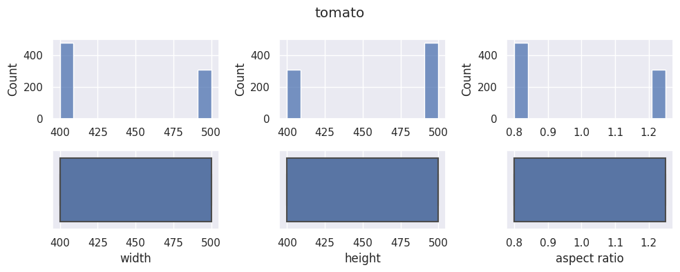

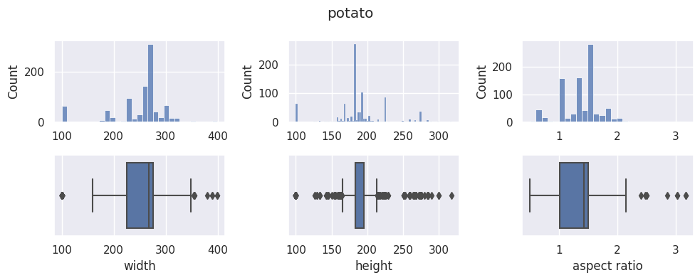

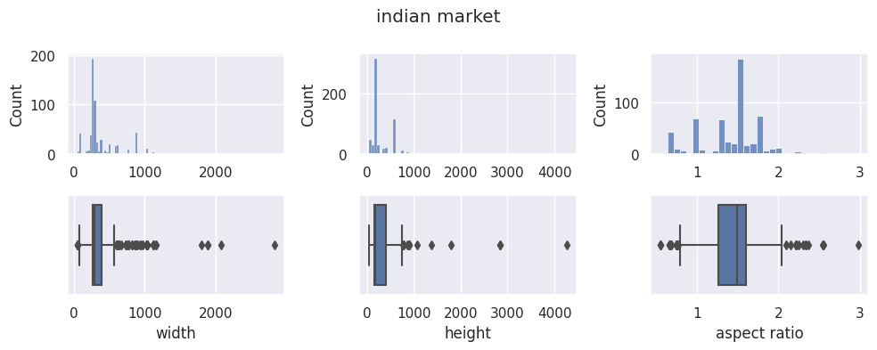

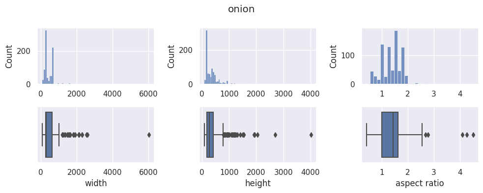

```python
# Visualize distribution of train image widths, heights, and aspect ratio


from IPython.display import Javascript
display(Javascript('''google.colab.output.setIframeHeight(0, true, {maxHeight: 5000})'''))

ddf = []
for cls in data_info['train'].keys():

  fig, axes = plt.subplots(2, 3, figsize=(10, 4))
  fig.suptitle(cls)

  widths = data_info['train'][cls]['image_sizes'][:, 0]
  heights = data_info['train'][cls]['image_sizes'][:, 1]
  aspect_ratio = np.round(widths / (heights + 0.01), 2)

  ddf.append([cls, 'width', np.min(widths), np.max(widths), np.mean(widths), np.std(widths)])
  ddf.append([cls, 'height', np.min(heights), np.max(heights), np.mean(heights), np.std(heights)])
  ddf.append([cls, 'aspect_ratio', np.min(aspect_ratio), np.max(aspect_ratio), np.mean(aspect_ratio), np.std(aspect_ratio)])

  sns.histplot(x = widths, ax=axes[0][0])
  sns.boxplot(x = widths, ax=axes[1][0])
  axes[1][0].set_xlabel(f'width')

  sns.histplot(x = heights, ax=axes[0][1])
  sns.boxplot(x = heights, ax=axes[1][1])
  axes[1][1].set_xlabel(f'height')

  sns.histplot(x = aspect_ratio, ax=axes[0][2])
  sns.boxplot(x = aspect_ratio, ax=axes[1][2])
  axes[1][2].set_xlabel(f'aspect ratio')

  plt.tight_layout()
  plt.show()
```

```python
# print image size stats
df = pd.DataFrame(ddf, columns=['class', 'attribute', 'min', 'max', 'mean', 'std'])
df.set_index(['class', 'attribute'])
```

| class | attribute | min | max | mean | std |
| --- | --- | --- | --- | --- | --- |
| tomato | width | 400.00 | 500.00 | 439.290241 | 48.839544 |
|  | height | 400.00 | 500.00 | 460.709759 | 48.839544 |
|  | aspect_ratio | 0.80 | 1.25 | 0.976806 | 0.219778 |
| potato | width | 100.00 | 399.00 | 250.178174 | 52.945716 |
|  | height | 100.00 | 318.00 | 188.674833 | 37.492197 |
|  | aspect_ratio | 0.50 | 3.17 | 1.358541 | 0.344736 |
| indian market | width | 48.00 | 2832.00 | 391.983306 | 278.758839 |
|  | height | 48.00 | 4256.00 | 304.696160 | 298.182185 |
|  | aspect_ratio | 0.56 | 2.98 | 1.408347 | 0.368655 |
| onion | width | 100.00 | 6030.00 | 460.209658 | 346.999358 |
|  | height | 100.00 | 4020.00 | 360.182568 | 293.242995 |
|  | aspect_ratio | 0.42 | 4.51 | 1.383004 | 0.406394 |

**Observations**

#### Plotting sample images

```
tomato
```

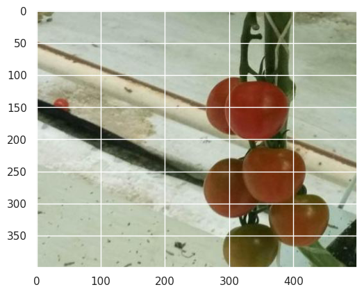

```
potato
```

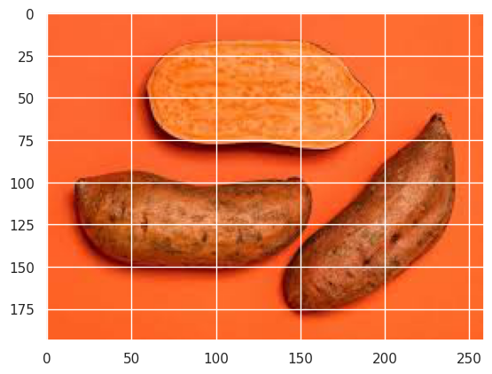

```
indian market
```

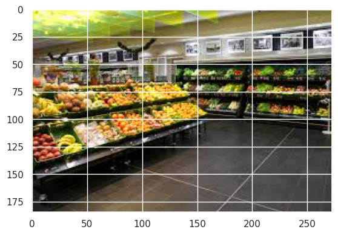

```
onion
```

[figure not shown]

```python
# plot sample images for each class
from IPython.display import Javascript
display(Javascript('''google.colab.output.setIframeHeight(0, true, {maxHeight: 5000})'''))

for cls in data_info['train'].keys():
  print(cls)
  plt.imshow(data_info['train'][cls]['sample_image'])
  plt.show()
```

### Create train, validation, test split

```python
def load_data(val_split = 0.2, image_size = (300, 300), batch_size=32):

    dev_data = tf.keras.utils.image_dataset_from_directory(
        f"{NJ_DATA_PATH}/train", shuffle=True, label_mode='categorical', image_size = image_size, batch_size = batch_size, crop_to_aspect_ratio=True
    )
    test_data = tf.keras.utils.image_dataset_from_directory(
        f"{NJ_DATA_PATH}/test", shuffle=False, label_mode='categorical', image_size = image_size, batch_size = batch_size, crop_to_aspect_ratio=True
    )

    train_split = 1 - val_split
    ds_size = len(dev_data)
    train_size = int(train_split * ds_size)
    val_size = ds_size - train_size

    train_data = dev_data.take(train_size)
    val_data = dev_data.skip(train_size).take(val_size)

    return train_data, val_data, test_data, dev_data.class_names
```

```python
batch_size = 32
print(f'Creating train, validation, and test sets with batchsize: {batch_size}')
train_data, val_data, test_data, classes = load_data(batch_size=batch_size)
print(f'Number of batches: train - {len(train_data)}, validation - {len(val_data)}, test - {len(test_data)}')
```

```
Creating train, validation, and test sets with batchsize: 32
Found 3135 files belonging to 4 classes.
Found 351 files belonging to 4 classes.
Number of batches: train - 78, validation - 20, test - 11
```

## Data pre-processing pipelines

```python
# Helper class to manage different data pre-processing pipelines
class DataPipelines:

  """
  th and tw are target image height and width respectively.
  input_shape - shape of input images in the dataset
  """
  def __init__(self, th, tw, input_shape=(300, 300, 3)):

    self.th = th
    self.tw = tw
    self.input_shape = input_shape

    #self.bbh = 1.2 * th if (bbh is None) else bbh
    #self.bbw = 1.2 * tw if (bbw is None) else bbw
    self.create_pipelines_models(th, tw, input_shape)
    self.create_pipelines()

  """
  creates diffenent preprocessing models for both training and inference
  """
  def create_pipelines_models(self, th, tw, input_shape):

    self.models = {

      'dp1': keras.Sequential(
          name="data_preprocess_basic_resize",
          layers=[
              layers.Resizing(th, tw, input_shape=input_shape),
              layers.Rescaling(1.0/255),
          ]
      ),
      'da1': keras.Sequential(
        name="data_augmentation_1",
        layers=[
            layers.Resizing(th, tw, input_shape=input_shape),
            layers.Rescaling(1.0/255),
        ]
      ),
      'da2': keras.Sequential(
        name="data_augmentation_2",
        layers=[
            layers.RandomCrop(th, tw, input_shape=input_shape),
            layers.Rescaling(1.0/255)
        ]
      ),
      'da3': keras.Sequential(
        name="data_augmentation_3",
        layers=[
            layers.RandomTranslation(height_factor = (-0.2, 0.3), width_factor = (-0.2, 0.3)),
            layers.RandomRotation(factor = (-0.2, 0.3)),
            layers.RandomFlip(),
            layers.RandomCrop(th, tw, input_shape=input_shape),
            layers.Rescaling(1.0/255)
        ]
      )
    }

  """
  creates named pair of pipelines corresponding to train and inference operations
  """
  def create_pipelines(self):
    self.pipelines = {
        'v1' : (self.models['da1'], self.models['dp1']),
        'v2' : (self.models['da2'], self.models['dp1']),
        'v3' : (self.models['da3'], self.models['dp1']),
    }

  """
  generator to yield all pipeline architectures
  """
  def get_all_pipelines(self):
    for pl_key in self.pipelines.keys():
      yield self.pipelines[pl_key]

  """
  returns a pipeline specificied by input name
  """
  def get_pipeline(self, name='v1'):
    return self.pipelines[name]
```

```python
#create an instance of data pipelines class to manage pre-processing pipelines
data_pipeline_helper = DataPipelines(224, 224, input_shape=(300, 300, 3))
```

```python
def get_preprocessed_datasets(pl_name):

  # fetch preprocessing pipelines
  train_pl, test_pl = data_pipeline_helper.get_pipeline(pl_name)

  # apply appropriate pipelines to train, test, and validation sets

  train_ds = train_data.map(
    lambda x, y: (train_pl(x), y), num_parallel_calls=tf.data.AUTOTUNE
  ).prefetch(tf.data.AUTOTUNE)

  val_ds = val_data.map(
    lambda x, y: (test_pl(x), y), num_parallel_calls=tf.data.AUTOTUNE
  ).prefetch(tf.data.AUTOTUNE)

  test_ds = test_data.map(
    lambda x, y: (test_pl(x), y), num_parallel_calls=tf.data.AUTOTUNE
  ).prefetch(tf.data.AUTOTUNE)

  return train_ds, val_ds, test_ds

train_ds1, val_ds1, test_ds1 = get_preprocessed_datasets('v1')
train_ds2, val_ds2, test_ds2 = get_preprocessed_datasets('v2')
train_ds3, val_ds3, test_ds3 = get_preprocessed_datasets('v3')
```

## Checkpoint and Model State helpers

```python
import shutil
import datetime as dt

class CheckpointHelper:

  def __init__(self, root_path):
    self.root_path = root_path
    self.checkpoints = {}

  def getCallback(self, model_name):
    if model_name not in self.checkpoints:

      cp_callback = tf.keras.callbacks.ModelCheckpoint(
          filepath=f'{self.root_path}/{model_name}',
          save_weights_only=True,
          verbose=1)

      self.checkpoints[model_name] = cp_callback

    return self.checkpoints[model_name]

  def getPath(self, model_name):
    return self.checkpoints[model_name]

checkpoint_helper = CheckpointHelper(CHECKPOINT_PATH)
```

```python
import pickle

#class to store relevant training history details
class ModelHistory(object):
  def __init__(self, history, epoch, params):
    self.history = history
    self.epoch = epoch
    self.params = params


def get_modelhistory_from_history(history):
  return ModelHistory(history.history, history.epoch, history.params)

# Helper class to save/load models
class ModelStateHelper:

  def __init__(self, remote_path):
    self.remote_path = remote_path

  # saves model history
  def save_model_history(self, model, save_path):

    with open(f'{save_path}/history', 'wb') as file:
      model_history= ModelHistory(model.history.history, model.history.epoch, model.history.params)
      pickle.dump(model_history, file, pickle.HIGHEST_PROTOCOL)

  # loads model history
  def load_model_history(self, save_path):

    with open(f'{save_path}/history', 'rb') as file:
      history=pickle.load(file)

    return history

  # saves model including history
  def save_model(self, model, model_name):

    save_path = f'{self.remote_path}/{model_name}'

    # if already exists, then rename it by appending its creation time at the end
    if(os.path.isdir(save_path)):
      ts = str(dt.datetime.fromtimestamp(os.path.getctime(save_path))) #read creation time
      os.rename(save_path, f'{save_path}_{ts}')

    # create a new empty directory
    os.makedirs(save_path)

    #save model
    model.save(save_path)

    #save history
    self.save_model_history(model, save_path)

  # loads model and its history details
  def load_model(self, model_name):

    save_path = f'{self.remote_path}/{model_name}'

    if(os.path.isdir(save_path)):

      model = tf.keras.models.load_model(save_path)
      history = self.load_model_history(save_path)

      return model, history

    return None, None

  def canloadsavedmodel(self, model_name):

    save_path = f'{self.remote_path}/{model_name}'
    return os.path.isdir(save_path)
    #return False


model_state_helper = ModelStateHelper(GDRIVE_SAVEDMODEL_PATH)
```

## Common Utility functions

```python
from sklearn.metrics import confusion_matrix, accuracy_score, precision_score, recall_score

# helper function to annotate maximum values in the plots
def annot_max(x,y, xytext=(0.94,0.96), ax=None, only_y=True):
    xmax = x[np.argmax(y)]
    ymax = max(y)
    if only_y:
        text = "{:.2f}%".format(ymax)
    else:
        text= "x={:.2f}, y={:.2f}%".format(xmax, ymax)
    if not ax:
        ax=plt.gca()
    bbox_props = dict(boxstyle="square,pad=0.3", fc="w", ec="k", lw=0.72)
    arrowprops=dict(arrowstyle="->",connectionstyle="angle,angleA=0,angleB=60")
    kw = dict(xycoords='data',textcoords="axes fraction",
              arrowprops=arrowprops, bbox=bbox_props, ha="right", va="top")
    ax.annotate(text, xy=(xmax, ymax), xytext=xytext, **kw)

# accuracy graph

def plot_accuracy(model_fit):

    x = range(0,len(model_fit.history['accuracy']))
    y_train = [acc * 100 for acc in model_fit.history['accuracy']]
    y_val = [acc * 100 for acc in model_fit.history['val_accuracy']]

    plt.plot(x, y_train, label='Train', color='b')
    annot_max(x, y_train, xytext=(0.7,0.9))
    plt.plot(x, y_val, label='Val', color='r')
    annot_max(x, y_val, xytext=(0.8,0.7))
    plt.ylabel('Accuracy', fontsize=15)
    plt.xlabel('epoch', fontsize=15)
    plt.legend()
    plt.show()

def plot_confusion_matrix(ylabels, ypred, class_names):
    cm = metrics.confusion_matrix(ylabels, ypred)
    sns.heatmap(cm, annot=True, xticklabels=class_names, yticklabels=class_names, cmap="YlGnBu", fmt='g')
    plt.show()

def get_ytrue_and_ypred(preds_ohe, dataset):

  # extract y_labels
  ytrue_ohe = np.concatenate([np.array(batch[1]) for batch in iter(dataset)])
  ytrue = tf.argmax(ytrue_ohe, axis=1)

  # extract y_pred
  ypred = tf.argmax(preds_ohe, axis=1)

  return ytrue, ypred

def predict_and_plot_confusion_matrix(model, dataset, class_names):

  preds = model.predict(dataset, verbose=2, use_multiprocessing=True)
  ytrue, ypred = get_ytrue_and_ypred(preds, dataset)
  plot_confusion_matrix(ytrue, ypred, class_names)

  acc = np.round(accuracy_score(ytrue, ypred), 3)
  precision = np.round(precision_score(ytrue, ypred, average='macro'), 2)
  recall = np.round(recall_score(ytrue, ypred, average='macro'), 2)

  classwise_scores = []

  print('')

  for ci in range(len(class_names)):
    ytrue_bin = list(map(lambda x: 1 if (x == ci) else 0, ytrue))
    ypred_bin = list(map(lambda x: 1 if (x == ci) else 0, ypred))

    classwise_scores.append((
        class_names[ci],
        np.round(precision_score(ytrue_bin, ypred_bin, average='binary'), 2),
        np.round(recall_score(ytrue_bin, ypred_bin, average='binary'), 2)
    ))

  print(pd.DataFrame(classwise_scores, columns=['class', 'precision', 'recall']))
  print(f'Overall accuracy: {np.round(acc * 100,2)}%, macro precision: {precision}, macro recall: {recall}')

  #return acc, precision, recall, ytrue, ypred

def training_plot(metrics, history):
  f, ax = plt.subplots(1, len(metrics), figsize=(5*len(metrics), 5))
  for idx, metric in enumerate(metrics):
    ax[idx].plot(history.history[metric], ls='dashed')
    ax[idx].set_xlabel("Epochs")
    ax[idx].set_ylabel(metric)
    ax[idx].plot(history.history['val_' + metric]);
    ax[idx].legend([metric, 'val_' + metric])

  plt.show()
```

```python
# Helper function to save/load, train, compile, and train model
def get_trained_model(model_name, create_model_fn, compile_model_fn, train_model_fn, train_set, val_set, force_train = False):

  if(not force_train and model_state_helper.canloadsavedmodel(model_name)):

    print('saved model found. loading it..')

    # load saved model and history
    model_pl, model_history = model_state_helper.load_model(model_name)

    # compile it
    compile_model_fn(model_pl)

  else:
    # create model
    model_pl = create_model_fn(model_name)

    # compile
    compile_model_fn(model_pl)

    # train
    history = train_model_fn(model_pl, train_set, val_set)

    model_history = get_modelhistory_from_history(history)

    #save model for future use
    print('saving model and history')
    model_state_helper.save_model(model_pl, model_name)

  return model_pl, model_history
```

```python
def get_compile_fn(model, optimizer='adam', loss='categorical_crossentropy', metrics=['accuracy']):
  return model.compile(
      optimizer=optimizer,
      loss = loss,
      metrics=metrics
    )

def model_fit_fn(model, train_data, val_data, epochs=5, callbacks=[]):
  return model.fit(
      train_data,
      epochs=epochs,
      validation_data=val_data,
      callbacks=callbacks
      )
```

## CNN model from scratch

Since the amount of training data is relatively small, to build a CNN classifier from scratch, we will choose a smaller architecture like Alexnet. The code below creates a model based on Alexnet architecture, trains it on the training dataset, and measures validation/test loss, as well as classification metrics such as accuracy, precision, and recall. We will use this model for benchmarking purpose.

```python
model_name = 'base_model_alexnet_v1'

def get_alexnet_model():
  return keras.models.Sequential([
    keras.layers.Resizing(64, 64),
    keras.layers.Conv2D(filters=128, kernel_size=(11,11), strides=(4,4), activation='relu', input_shape=(64,64,3)),
    keras.layers.BatchNormalization(),
    keras.layers.MaxPool2D(pool_size=(2,2)),
    keras.layers.Conv2D(filters=256, kernel_size=(5,5), strides=(1,1), activation='relu', padding="same"),
    keras.layers.BatchNormalization(),
    keras.layers.MaxPool2D(pool_size=(3,3)),
    keras.layers.Conv2D(filters=256, kernel_size=(3,3), strides=(1,1), activation='relu', padding="same"),
    keras.layers.BatchNormalization(),
    keras.layers.Conv2D(filters=256, kernel_size=(1,1), strides=(1,1), activation='relu', padding="same"),
    keras.layers.BatchNormalization(),
    keras.layers.Conv2D(filters=256, kernel_size=(1,1), strides=(1,1), activation='relu', padding="same"),
    keras.layers.BatchNormalization(),
    keras.layers.MaxPool2D(pool_size=(2,2)),
    keras.layers.Flatten(),
    keras.layers.Dense(1024,activation='relu'),
    keras.layers.Dropout(0.5),
    keras.layers.Dense(1024,activation='relu'),
    keras.layers.Dropout(0.5),
    keras.layers.Dense(4,activation='softmax')
  ])

optimizer = keras.optimizers.Adam(learning_rate=0.0005)

base_model_v1, model_history = get_trained_model(

    model_name,

    # create_model_fn
    lambda model_name: get_alexnet_model(),

    # compile_model_fn
    lambda model: get_compile_fn(model, optimizer=optimizer),

    # train_model_fn
    lambda model, train_data, val_data: model_fit_fn(model, train_data, val_data, epochs=10),

    #training data
    train_ds1,

    #validation data
    val_ds1,

    )
```

```
saved model found. loading it..
```

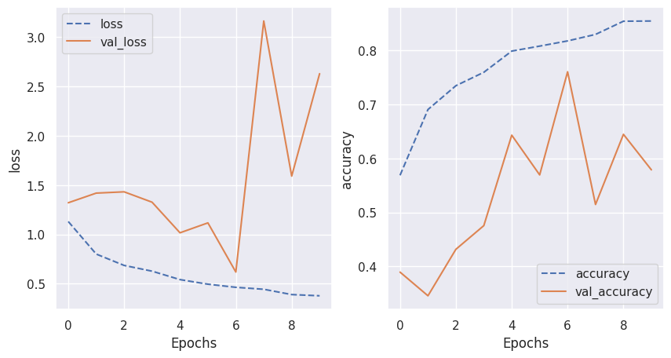

```
11/11 - 8s - 8s/epoch - 700ms/step
```

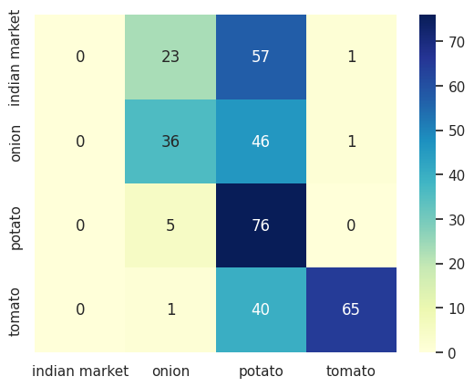

```
           class  precision  recall
0  indian market       0.00    0.00
1          onion       0.55    0.43
2         potato       0.35    0.94
3         tomato       0.97    0.61
Overall accuracy: 50.4%, macro precision: 0.47, macro recall: 0.5
```

```python
# Evaluate the model training plot
training_plot(['loss', 'accuracy'], model_history)
predict_and_plot_confusion_matrix(base_model_v1, test_ds1, classes)
```

**Observation:**

Our base CNN model produces ~58% accuracy on validation data and ~50% accuracy on test data. The model is extremely biased against 'Indian market' class with zero TP. From the training plot we can observe that validation loss fluctuated a lot. We can try to address this by adding 'ReduceLROnPlateau' LR scheduler and earlystopping. We will also increase batch_size to 64 to see if that can help reduce fluctuations.

```python
model_name = 'base_model_alexnet_v2'

callbacks = [
  keras.callbacks.ReduceLROnPlateau(
    monitor="val_loss", factor=0.3, patience=5, min_lr=0.00005
  ),
  keras.callbacks.EarlyStopping(
    monitor="val_loss", patience=10, min_delta=0.001, mode='min'
  )
]

optimizer = keras.optimizers.Adam(learning_rate=0.001)

base_model_v2, model_history = get_trained_model(

    model_name,

    # create_model_fn
    lambda model_name: get_alexnet_model(),

    # compile_model_fn
    lambda model: get_compile_fn(model, optimizer=optimizer),

    # train_model_fn
    lambda model, train_data, val_data: model_fit_fn(model, train_data, val_data, epochs=10, callbacks=callbacks),

    #training data
    train_ds1.unbatch().batch(64),

    #validation data
    val_ds1.unbatch().batch(64),

    force_train = True

    )
```

```
saving model and history
```

```
WARNING:absl:Found untraced functions such as _jit_compiled_convolution_op, _jit_compiled_convolution_op, _jit_compiled_convolution_op, _jit_compiled_convolution_op, _jit_compiled_convolution_op while saving (showing 5 of 6). These functions will not be directly callable after loading.
```

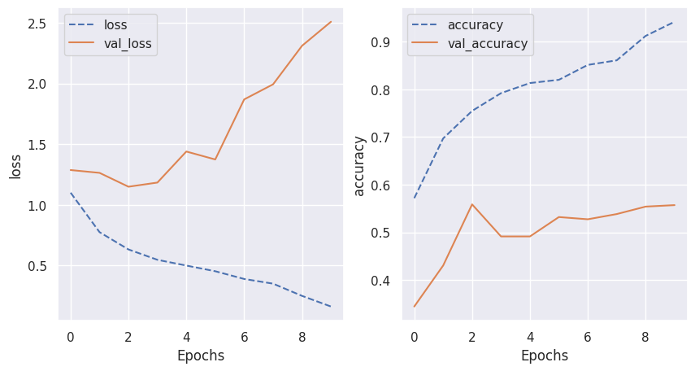

```
11/11 - 2s - 2s/epoch - 137ms/step
```

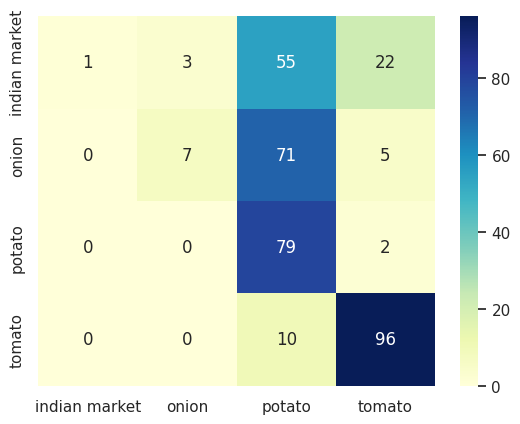

```
           class  precision  recall
0  indian market       1.00    0.01
1          onion       0.70    0.08
2         potato       0.37    0.98
3         tomato       0.77    0.91
Overall accuracy: 52.1%, macro precision: 0.71, macro recall: 0.49
```

```python
# Evaluate the model training plot
training_plot(['loss', 'accuracy'], model_history)
predict_and_plot_confusion_matrix(base_model_v2, test_ds1, classes)
```

**Observation**

```python
#adding L2 regularization to CNN
from tensorflow.keras import regularizers

def get_alexnet_model_v3():
  penalty_fact = 1e-5
  return keras.models.Sequential([
    keras.layers.Resizing(64, 64),
    keras.layers.Conv2D(filters=128, kernel_size=(11,11), strides=(4,4), activation='relu', input_shape=(64,64,3), kernel_regularizer=regularizers.l2(penalty_fact)),
    keras.layers.BatchNormalization(),
    keras.layers.MaxPool2D(pool_size=(2,2)),
    keras.layers.Conv2D(filters=256, kernel_size=(5,5), strides=(1,1), activation='relu', padding="same", kernel_regularizer=regularizers.l2(penalty_fact)),
    keras.layers.BatchNormalization(),
    keras.layers.MaxPool2D(pool_size=(3,3)),
    keras.layers.Conv2D(filters=256, kernel_size=(3,3), strides=(1,1), activation='relu', padding="same", kernel_regularizer=regularizers.l2(penalty_fact)),
    keras.layers.BatchNormalization(),
    keras.layers.Conv2D(filters=256, kernel_size=(1,1), strides=(1,1), activation='relu', padding="same", kernel_regularizer=regularizers.l2(penalty_fact)),
    keras.layers.BatchNormalization(),
    keras.layers.Conv2D(filters=256, kernel_size=(1,1), strides=(1,1), activation='relu', padding="same", kernel_regularizer=regularizers.l2(penalty_fact)),
    keras.layers.BatchNormalization(),
    keras.layers.MaxPool2D(pool_size=(2,2)),
    keras.layers.Flatten(),
    keras.layers.Dense(1024,activation='relu', kernel_regularizer=regularizers.l2(penalty_fact)),
    keras.layers.Dropout(0.5),
    keras.layers.Dense(1024,activation='relu', kernel_regularizer=regularizers.l2(penalty_fact)),
    keras.layers.Dropout(0.5),
    keras.layers.Dense(4,activation='softmax')
  ])

optimizer = keras.optimizers.Adam(learning_rate=0.0005)

callbacks = [
  keras.callbacks.ReduceLROnPlateau(
    monitor="val_loss", factor=0.3, patience=5, min_lr=0.000005
  ),
  keras.callbacks.EarlyStopping(
    monitor="val_loss", patience=5, min_delta=0.001, mode='min', restore_best_weights=True
  )
]

model_name = 'base_model_alexnet_v3'

base_model_v3, model_history = get_trained_model(

    model_name,

    # create_model_fn
    lambda model_name: get_alexnet_model_v3(),

    # compile_model_fn
    lambda model: get_compile_fn(model, optimizer=optimizer),

    # train_model_fn
    lambda model, train_data, val_data: model_fit_fn(model, train_data, val_data, epochs=20, callbacks=callbacks),

    #training data
    train_ds1.unbatch().batch(64),

    #validation data
    val_ds1.unbatch().batch(64),

    )
```

```
saving model and history
```

```
WARNING:absl:Found untraced functions such as _jit_compiled_convolution_op, _jit_compiled_convolution_op, _jit_compiled_convolution_op, _jit_compiled_convolution_op, _jit_compiled_convolution_op while saving (showing 5 of 6). These functions will not be directly callable after loading.
```

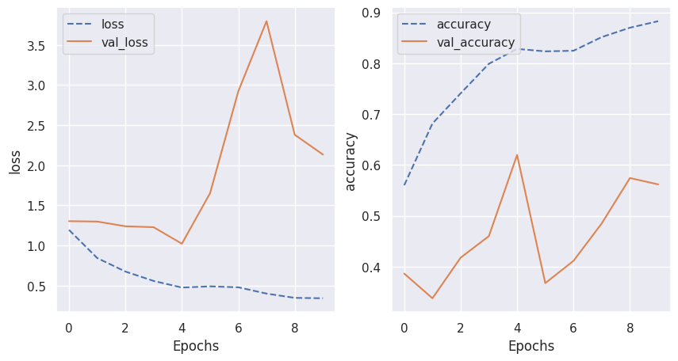

```
11/11 - 3s - 3s/epoch - 234ms/step
```

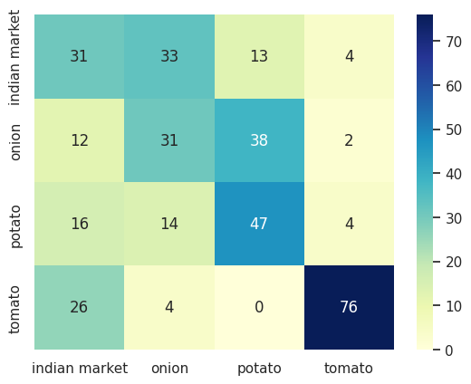

```
           class  precision  recall
0  indian market       0.36    0.38
1          onion       0.38    0.37
2         potato       0.48    0.58
3         tomato       0.88    0.72
Overall accuracy: 52.7%, macro precision: 0.53, macro recall: 0.51
```

```python
# Evaluate the model training plot
training_plot(['loss', 'accuracy'], model_history)
predict_and_plot_confusion_matrix(base_model_v3, test_ds1, classes)
```

**Observation:**

```python
model_name = 'base_model_alexnet_v2.1'

callbacks = [
  keras.callbacks.ReduceLROnPlateau(
    monitor="val_loss", factor=0.3, patience=5, min_lr=0.0001
  ),
  keras.callbacks.EarlyStopping(
    monitor="val_loss", patience=10, min_delta=0.001, mode='min'
  )
]

optimizer = keras.optimizers.Adam(learning_rate=0.0005)

base_model_v21, model_history = get_trained_model(

    model_name,

    # create_model_fn
    lambda model_name: get_alexnet_model(),

    # compile_model_fn
    lambda model: get_compile_fn(model, optimizer=optimizer),

    # train_model_fn
    lambda model, train_data, val_data: model_fit_fn(model, train_data, val_data, epochs=10, callbacks=callbacks),

    #training data
    train_ds3.unbatch().batch(64),

    #validation data
    val_ds3.unbatch().batch(64),

    )
```

```
saving model and history
```

```
WARNING:absl:Found untraced functions such as _jit_compiled_convolution_op, _jit_compiled_convolution_op, _jit_compiled_convolution_op, _jit_compiled_convolution_op, _jit_compiled_convolution_op while saving (showing 5 of 6). These functions will not be directly callable after loading.
```

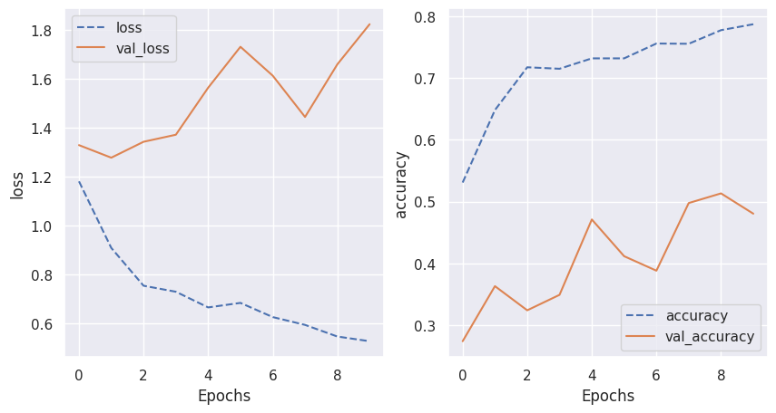

```
11/11 - 2s - 2s/epoch - 148ms/step
```

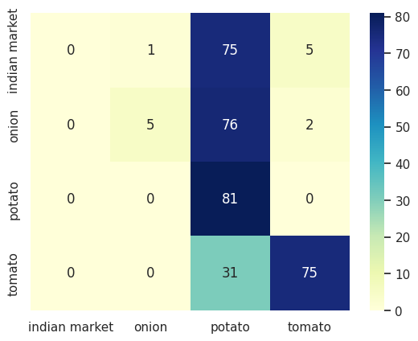

```
           class  precision  recall
0  indian market       0.00    0.00
1          onion       0.83    0.06
2         potato       0.31    1.00
3         tomato       0.91    0.71
Overall accuracy: 45.9%, macro precision: 0.51, macro recall: 0.44
```

```python
# Evaluate the model training plot
training_plot(['loss', 'accuracy'], model_history)
predict_and_plot_confusion_matrix(base_model_v21, test_ds3, classes)
```

## Extending VGGNet-19

#### Load vgg19 pretrained model

```python
pretrained_vgg19 = tf.keras.applications.vgg19.VGG19(weights='imagenet', include_top=False, input_shape=[224,224,3])
pretrained_vgg19.trainable=False

pretrained_vgg19.summary()
```

```
Downloading data from https://storage.googleapis.com/tensorflow/keras-applications/vgg19/vgg19_weights_tf_dim_ordering_tf_kernels_notop.h5
Model: "vgg19"
_________________________________________________________________
 Layer (type)                Output Shape              Param #
=================================================================
 input_1 (InputLayer)        [(None, 224, 224, 3)]     0

 block1_conv1 (Conv2D)       (None, 224, 224, 64)      1792

 block1_conv2 (Conv2D)       (None, 224, 224, 64)      36928

 block1_pool (MaxPooling2D)  (None, 112, 112, 64)      0

 block2_conv1 (Conv2D)       (None, 112, 112, 128)     73856

 block2_conv2 (Conv2D)       (None, 112, 112, 128)     147584

 block2_pool (MaxPooling2D)  (None, 56, 56, 128)       0

 block3_conv1 (Conv2D)       (None, 56, 56, 256)       295168

 block3_conv2 (Conv2D)       (None, 56, 56, 256)       590080

 block3_conv3 (Conv2D)       (None, 56, 56, 256)       590080

 block3_conv4 (Conv2D)       (None, 56, 56, 256)       590080

 block3_pool (MaxPooling2D)  (None, 28, 28, 256)       0

 block4_conv1 (Conv2D)       (None, 28, 28, 512)       1180160

 block4_conv2 (Conv2D)       (None, 28, 28, 512)       2359808

 block4_conv3 (Conv2D)       (None, 28, 28, 512)       2359808

 block4_conv4 (Conv2D)       (None, 28, 28, 512)       2359808

 block4_pool (MaxPooling2D)  (None, 14, 14, 512)       0

 block5_conv1 (Conv2D)       (None, 14, 14, 512)       2359808

 block5_conv2 (Conv2D)       (None, 14, 14, 512)       2359808

 block5_conv3 (Conv2D)       (None, 14, 14, 512)       2359808

 block5_conv4 (Conv2D)       (None, 14, 14, 512)       2359808

 block5_pool (MaxPooling2D)  (None, 7, 7, 512)         0

=================================================================
Total params: 20,024,384
Trainable params: 0
Non-trainable params: 20,024,384
_________________________________________________________________
```

### Baseline model - V1

We will first create a baseline model which simply flattens the output of pre-trained vgg19 model and connects it with output layer with 4 classes. We will also apply LR scheduler, early stopping, and model checkpoint callbacks.

```python
model_name = 'vgg19_v1'

callbacks = [
  keras.callbacks.ReduceLROnPlateau(
    monitor="val_loss", factor=0.3, patience=5, min_lr=0.000005
  ),
  keras.callbacks.EarlyStopping(
    monitor="val_loss", patience=5, min_delta=0.001, mode='min', restore_best_weights=True
  ),
  checkpoint_helper.getCallback(model_name)
]

optimizer = keras.optimizers.Adam(learning_rate=0.0005)

vgg19_model_v1, model_history = get_trained_model(

    model_name,

    # create_model_fn
    lambda model_name: tf.keras.Sequential(
      name=model_name,
      layers=[
          pretrained_vgg19,
          tf.keras.layers.Flatten(),
          tf.keras.layers.Dense(4, activation='softmax')]
      ),

    # compile_model_fn
    lambda model: get_compile_fn(model, optimizer=optimizer),

    # train_model_fn
    lambda model, train_data, val_data: model_fit_fn(model, train_data, val_data, epochs=10, callbacks=callbacks),

    #training data
    train_ds1,

    #validation data
    val_ds1
    )
```

```
Epoch 1: saving model to ./checkpoints_test/vgg19_v1
Epoch 2: saving model to ./checkpoints_test/vgg19_v1
Epoch 3: saving model to ./checkpoints_test/vgg19_v1
Epoch 4: saving model to ./checkpoints_test/vgg19_v1
Epoch 5: saving model to ./checkpoints_test/vgg19_v1
Epoch 6: saving model to ./checkpoints_test/vgg19_v1
Epoch 7: saving model to ./checkpoints_test/vgg19_v1
Epoch 8: saving model to ./checkpoints_test/vgg19_v1
Epoch 9: saving model to ./checkpoints_test/vgg19_v1
Epoch 10: saving model to ./checkpoints_test/vgg19_v1
saving model and history
```

```
WARNING:absl:Found untraced functions such as _jit_compiled_convolution_op, _jit_compiled_convolution_op, _jit_compiled_convolution_op, _jit_compiled_convolution_op, _jit_compiled_convolution_op while saving (showing 5 of 16). These functions will not be directly callable after loading.
```

```python
vgg19_model_v1.summary()
```

```
Model: "vgg19_v1"
_________________________________________________________________
 Layer (type)                Output Shape              Param #
=================================================================
 vgg19 (Functional)          (None, 7, 7, 512)         20024384

 flatten_6 (Flatten)         (None, 25088)             0

 dense_18 (Dense)            (None, 4)                 100356

=================================================================
Total params: 20,124,740
Trainable params: 100,356
Non-trainable params: 20,024,384
_________________________________________________________________
```

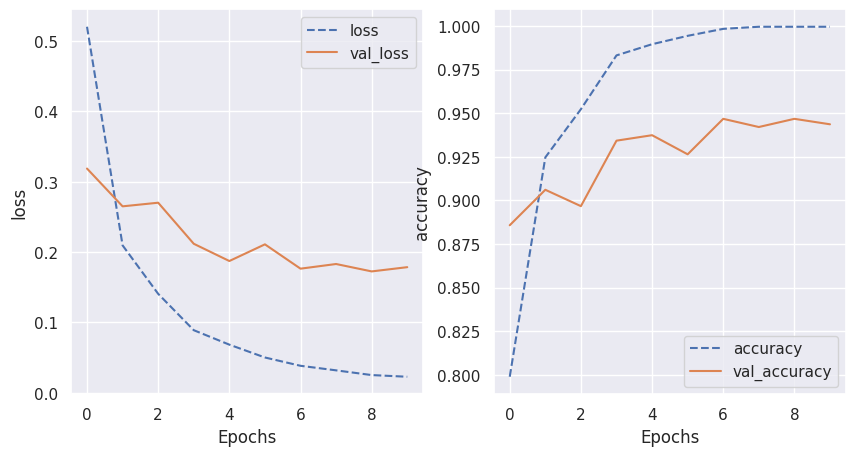

```
11/11 - 2s - 2s/epoch - 188ms/step
```

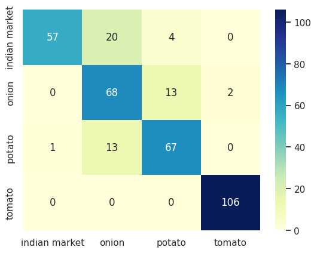

```
           class  precision  recall
0  indian market       0.98    0.70
1          onion       0.67    0.82
2         potato       0.80    0.83
3         tomato       0.98    1.00
Overall accuracy: 84.9%, macro precision: 0.86, macro recall: 0.84
```

```python
# Evaluate the model training plot
training_plot(['loss', 'accuracy'], model_history)
predict_and_plot_confusion_matrix(vgg19_model_v1, test_ds2, classes)
```

**Observation**

Out model reports validation accuracy of 94% and test accuracy of ~85%. It also seems much more balanced in its prediction compared to the base model.

The model has 100,356 trainable parameters. Let's try to reduce the number of trainable parameters by adding global average pooling at the end of vgg model and check its performance.

### VGG19 v2 - global average pooling

```python
model_name = 'vgg19_v2'

optimizer = keras.optimizers.Adam(learning_rate=0.0005)

vgg19_model_v2, model_history = get_trained_model(

    model_name,

    # create_model_fn
    lambda model_name: tf.keras.Sequential(
      name=model_name,
      layers=[
          pretrained_vgg19,
          tf.keras.layers.GlobalAveragePooling2D(),
          tf.keras.layers.Flatten(),
          tf.keras.layers.Dense(4, activation='softmax')]
      ),

    # compile_model_fn
    lambda model: get_compile_fn(model, optimizer=optimizer),

    # train_model_fn
    lambda model, train_data, val_data: model_fit_fn(model, train_data, val_data, epochs=10, callbacks=callbacks),

    #training data
    train_ds1,

    #validation data
    val_ds1
    )
```

```
saved model found. loading it..
```

```python
vgg19_model_v2.summary()
```

```
Model: "vgg19_v2"
_________________________________________________________________
 Layer (type)                Output Shape              Param #
=================================================================
 vgg19 (Functional)          (None, 7, 7, 512)         20024384

 global_average_pooling2d (G  (None, 512)              0
 lobalAveragePooling2D)

 flatten_7 (Flatten)         (None, 512)               0

 dense_19 (Dense)            (None, 4)                 2052

=================================================================
Total params: 20,026,436
Trainable params: 2,052
Non-trainable params: 20,024,384
_________________________________________________________________
```

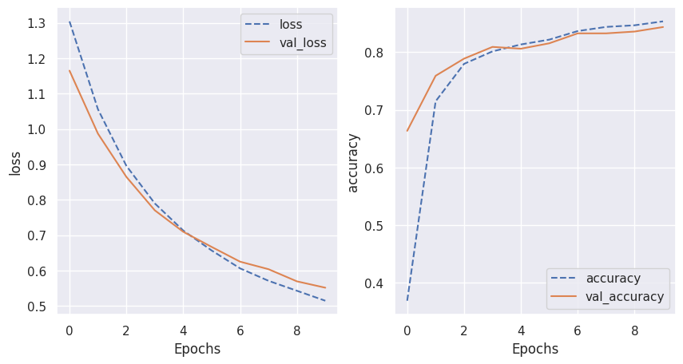

```
11/11 - 2s - 2s/epoch - 183ms/step
```

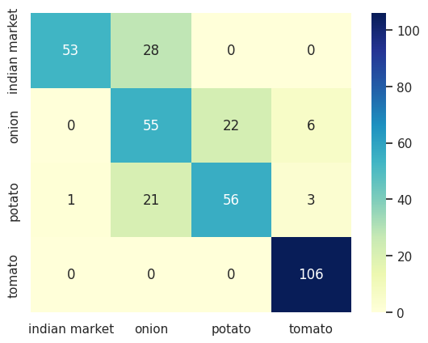

```
           class  precision  recall
0  indian market       0.98    0.65
1          onion       0.53    0.66
2         potato       0.72    0.69
3         tomato       0.92    1.00
Overall accuracy: 76.9%, macro precision: 0.79, macro recall: 0.75
```

```python
# Evaluate the model training plot
training_plot(['loss', 'accuracy'], model_history)
predict_and_plot_confusion_matrix(vgg19_model_v2, test_ds1, classes)
```

**Observation:**

From the training plots we can see that both training and validation losses had smoother, gradual decrease, and accuracy curves increased gradually as well. We try running the same model for a few more epochs to check if the performance improves further.

```python
model_history2 = vgg19_model_v2.fit(
      train_ds1,
      epochs=10,
      validation_data=val_ds1,
      callbacks=callbacks
      )
```

[output not shown]

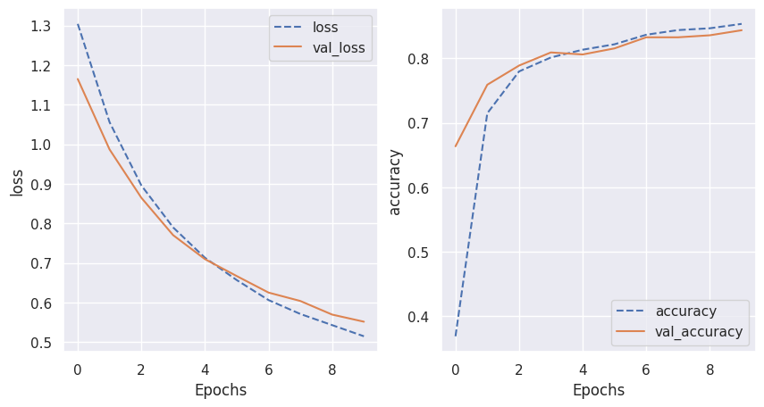

```
11/11 - 2s - 2s/epoch - 159ms/step
```

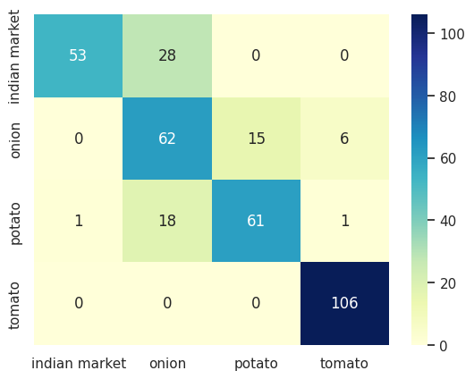

```
           class  precision  recall
0  indian market       0.98    0.65
1          onion       0.57    0.75
2         potato       0.80    0.75
3         tomato       0.94    1.00
Overall accuracy: 80.3%, macro precision: 0.82, macro recall: 0.79
```

```python
# Evaluate the model training plot
training_plot(['loss', 'accuracy'], model_history)
predict_and_plot_confusion_matrix(vgg19_model_v2, test_ds1, classes)
```

**Observations**

```python
#train on augmented dataset

model_name = 'vgg19_v2.1'

optimizer = keras.optimizers.Adam(learning_rate=0.0005)

vgg19_model_v2_1, model_history = get_trained_model(

    model_name,

    # create_model_fn
    lambda model_name: tf.keras.Sequential(
      name=model_name,
      layers=[
          pretrained_vgg19,
          tf.keras.layers.GlobalAveragePooling2D(),
          tf.keras.layers.Flatten(),
          tf.keras.layers.Dense(4, activation='softmax')]
      ),

    # compile_model_fn
    lambda model: get_compile_fn(model, optimizer=optimizer),

    # train_model_fn
    lambda model, train_data, val_data: model_fit_fn(model, train_data, val_data, epochs=20, callbacks=callbacks),

    #training data
    train_ds3,

    #validation data
    val_ds3,

    )
```

```
Epoch 1: saving model to ./checkpoints_test/vgg19_v1
Epoch 2: saving model to ./checkpoints_test/vgg19_v1
Epoch 3: saving model to ./checkpoints_test/vgg19_v1
Epoch 4: saving model to ./checkpoints_test/vgg19_v1
Epoch 5: saving model to ./checkpoints_test/vgg19_v1
Epoch 6: saving model to ./checkpoints_test/vgg19_v1
Epoch 7: saving model to ./checkpoints_test/vgg19_v1
Epoch 8: saving model to ./checkpoints_test/vgg19_v1
Epoch 9: saving model to ./checkpoints_test/vgg19_v1
Epoch 10: saving model to ./checkpoints_test/vgg19_v1
Epoch 11: saving model to ./checkpoints_test/vgg19_v1
Epoch 12: saving model to ./checkpoints_test/vgg19_v1
Epoch 13: saving model to ./checkpoints_test/vgg19_v1
Epoch 14: saving model to ./checkpoints_test/vgg19_v1
Epoch 15: saving model to ./checkpoints_test/vgg19_v1
Epoch 16: saving model to ./checkpoints_test/vgg19_v1
Epoch 17: saving model to ./checkpoints_test/vgg19_v1
Epoch 18: saving model to ./checkpoints_test/vgg19_v1
Epoch 19: saving model to ./checkpoints_test/vgg19_v1
Epoch 20: saving model to ./checkpoints_test/vgg19_v1
saving model and history
```

```
WARNING:absl:Found untraced functions such as _jit_compiled_convolution_op, _jit_compiled_convolution_op, _jit_compiled_convolution_op, _jit_compiled_convolution_op, _jit_compiled_convolution_op while saving (showing 5 of 16). These functions will not be directly callable after loading.
```

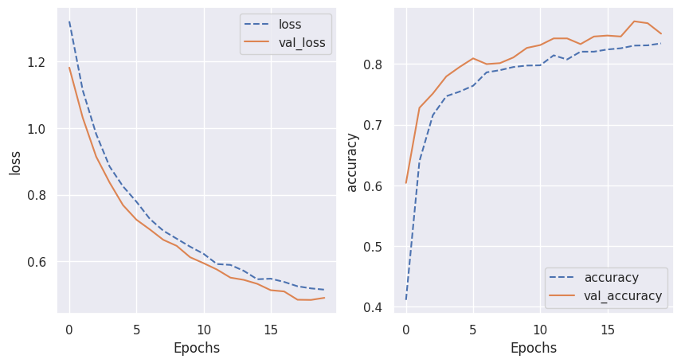

```
11/11 - 3s - 3s/epoch - 279ms/step
```

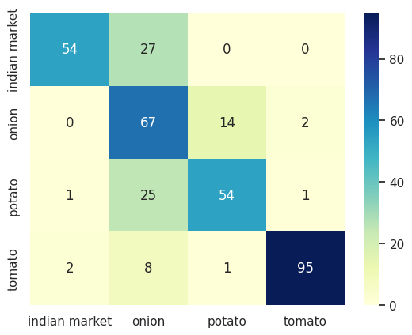

```
           class  precision  recall
0  indian market       0.95    0.67
1          onion       0.53    0.81
2         potato       0.78    0.67
3         tomato       0.97    0.90
Overall accuracy: 76.9%, macro precision: 0.81, macro recall: 0.76
```

```python
training_plot(['loss', 'accuracy'], model_history)
predict_and_plot_confusion_matrix(vgg19_model_v2_1, test_ds3, classes)
```

**Observations:**

We observe that data augmentation didn't improve the overall accuracy Infact, it has degraded the accuracy by 3 percent points. Next, we will try adding an additional dense layer in the custom model, and also adding dropouts after each dense layer.

```python
#add a fully connected layer in classifier head.

model_name = 'vgg19_v3'

optimizer = keras.optimizers.Adam(learning_rate=0.0005)

vgg19_model_v3, model_history = get_trained_model(

    model_name,

    # create_model_fn
    lambda model_name: tf.keras.Sequential(
      name=model_name,
      layers=[
          pretrained_vgg19,
          tf.keras.layers.GlobalAveragePooling2D(),
          tf.keras.layers.Flatten(),
          tf.keras.layers.Dropout(0.2),
          tf.keras.layers.Dense(1024, activation='relu'),
          tf.keras.layers.Dropout(0.2),
          tf.keras.layers.Dense(4, activation='softmax')]
      ),

    # compile_model_fn
    lambda model: get_compile_fn(model, optimizer=optimizer),

    # train_model_fn
    lambda model, train_data, val_data: model_fit_fn(model, train_data, val_data, epochs=10, callbacks=callbacks),

    #training data
    train_ds1,

    #validation data
    val_ds1,

    )
```

```
saved model found. loading it..
```

```python
vgg19_model_v3.summary()
```

```
Model: "vgg19_v3"
_________________________________________________________________
 Layer (type)                Output Shape              Param #
=================================================================
 vgg19 (Functional)          (None, 7, 7, 512)         20024384

 global_average_pooling2d_2   (None, 512)              0
 (GlobalAveragePooling2D)

 flatten_9 (Flatten)         (None, 512)               0

 dropout_12 (Dropout)        (None, 512)               0

 dense_21 (Dense)            (None, 1024)              525312

 dropout_13 (Dropout)        (None, 1024)              0

 dense_22 (Dense)            (None, 4)                 4100

=================================================================
Total params: 20,553,796
Trainable params: 529,412
Non-trainable params: 20,024,384
_________________________________________________________________
```

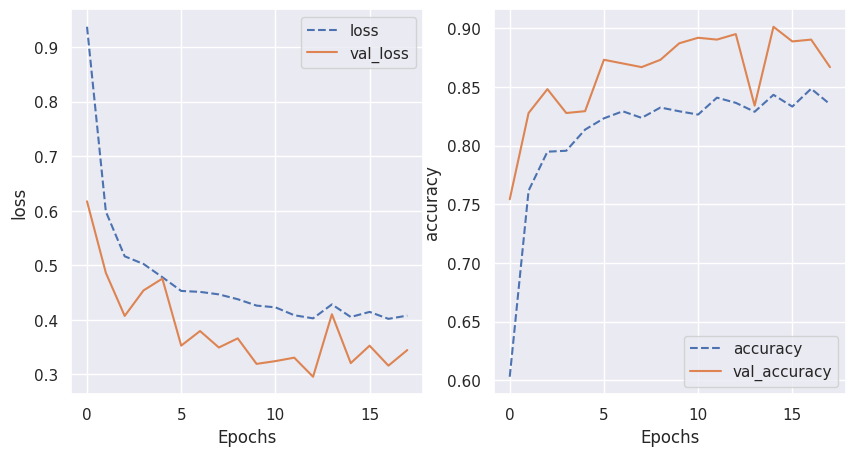

```
11/11 - 24s - 24s/epoch - 2s/step
```

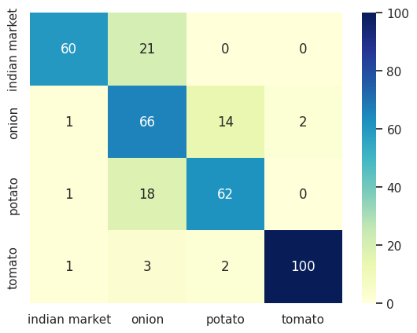

```
           class  precision  recall
0  indian market       0.95    0.74
1          onion       0.61    0.80
2         potato       0.79    0.77
3         tomato       0.98    0.94
Overall accuracy: 82.1%, macro precision: 0.83, macro recall: 0.81
```

```python
training_plot(['loss', 'accuracy'], model_history)
predict_and_plot_confusion_matrix(vgg19_model_v3, test_ds3, classes)
```

**Observation:**

We see that test accuracy is 82% while the validation accuracy is 0.87. While this is better compared to the V2 model, overall, V1 model provides highest test accuracy at ~85%

## Extending Efficientnet

In this section, we will extend pretrained efficientnet V2 B0 architecture.

#### Load EfficientNet pretrained model

```python
#!pip install -U efficientnet
from tensorflow.keras.applications import EfficientNetV2B0

#from tensorflow.keras.applications.EfficientNetB0 import EfficientNetB0 as efn

pretrained_efn = EfficientNetV2B0(
    input_shape = (224, 224, 3),
    include_top = False,
    weights = 'imagenet')

pretrained_efn.trainable=False

pretrained_efn.summary()
```

[output not shown]

[output cut: 663 more lines]

```

 block6h_add (Add)              (None, 7, 7, 192)    0           ['block6h_drop[0][0]',
                                                                  'block6g_add[0][0]']

 top_conv (Conv2D)              (None, 7, 7, 1280)   245760      ['block6h_add[0][0]']

 top_bn (BatchNormalization)    (None, 7, 7, 1280)   5120        ['top_conv[0][0]']

 top_activation (Activation)    (None, 7, 7, 1280)   0           ['top_bn[0][0]']

==================================================================================================
Total params: 5,919,312
Trainable params: 0
Non-trainable params: 5,919,312
__________________________________________________________________________________________________
```

```python
model_name = 'efn_v1'

callbacks = [
  keras.callbacks.ReduceLROnPlateau(
    monitor="val_loss", factor=0.3, patience=5, min_lr=0.000005
  ),
  keras.callbacks.EarlyStopping(
    monitor="val_loss", patience=5, min_delta=0.001, mode='min', restore_best_weights=True
  ),
  checkpoint_helper.getCallback(model_name)
]

optimizer = keras.optimizers.Adam(learning_rate=0.01)

efn_v1, model_history = get_trained_model(

    model_name,

    # create_model_fn
    lambda model_name: tf.keras.Sequential(
      name=model_name,
      layers=[
          pretrained_efn,
          tf.keras.layers.GlobalMaxPooling2D(),
          tf.keras.layers.Dense(256, activation='relu'),
          tf.keras.layers.BatchNormalization(),
          tf.keras.layers.Flatten(),
          tf.keras.layers.Dense(4, activation='softmax')]
      ),

    # compile_model_fn
    lambda model: get_compile_fn(model, optimizer=optimizer),

    # train_model_fn
    lambda model, train_data, val_data: model_fit_fn(model, train_data, val_data, epochs=15, callbacks=[]),

    #training data
    train_ds1.unbatch().batch(64),

    #validation data
    val_ds1.unbatch().batch(64),

    force_train = True
    )
```

```
saving model and history
```

```
WARNING:absl:Function `_wrapped_model` contains input name(s) efficientnetv2-b0_input with unsupported characters which will be renamed to efficientnetv2_b0_input in the SavedModel.
WARNING:absl:`efficientnetv2-b0_input` is not a valid tf.function parameter name. Sanitizing to `efficientnetv2_b0_input`.
WARNING:absl:`efficientnetv2-b0_input` is not a valid tf.function parameter name. Sanitizing to `efficientnetv2_b0_input`.
WARNING:absl:Found untraced functions such as _jit_compiled_convolution_op, _jit_compiled_convolution_op, _jit_compiled_convolution_op, _jit_compiled_convolution_op, _jit_compiled_convolution_op while saving (showing 5 of 91). These functions will not be directly callable after loading.
```

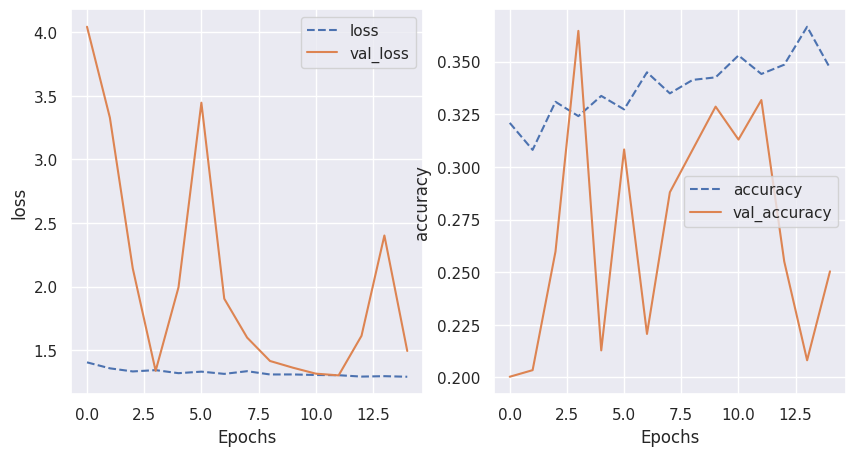

```
11/11 - 4s - 4s/epoch - 392ms/step
```

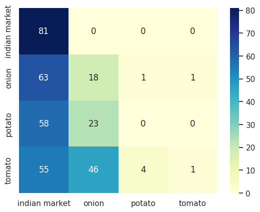

```
           class  precision  recall
0  indian market       0.32    1.00
1          onion       0.21    0.22
2         potato       0.00    0.00
3         tomato       0.50    0.01
Overall accuracy: 28.5%, macro precision: 0.26, macro recall: 0.31
```

```python
training_plot(['loss', 'accuracy'], model_history)
predict_and_plot_confusion_matrix(efn_v1, test_ds3, classes)
```

**Observations:**

Surprisingly, our custom model based on the pretrained efficientnet V2 B0 model works very poorly. We tried several tricks: adjusting learning rate, changing batch size, applying data augmentation, adding denser fully connected layer (upto 1024), batch normalization, dropouts, etc (These were tried offline and not captured in this notebook). None of the options helped improve validation/test accuracy. The validation score always seemed to hover in the 0.2 - 0.35 range, while test score in the range 0.25-0.3. We need more investigation to understand what could be the issue for poor performance.

## Extending Resnet50

Finally, in this section we will extend pretrained Resnet50V2 model. In this section, we will also use Tensorboard callback to track of training progress.

```python
from tensorflow.keras.applications import ResNet50V2

pretrained_resnet = ResNet50V2(
    input_shape = (224, 224, 3),
    include_top = False,
    weights = 'imagenet')

pretrained_resnet.trainable=False

pretrained_resnet.summary()
```

[output not shown]

[output cut: 491 more lines]

```

 conv5_block3_3_conv (Conv2D)   (None, 7, 7, 2048)   1050624     ['conv5_block3_2_relu[0][0]']

 conv5_block3_out (Add)         (None, 7, 7, 2048)   0           ['conv5_block2_out[0][0]',
                                                                  'conv5_block3_3_conv[0][0]']

 post_bn (BatchNormalization)   (None, 7, 7, 2048)   8192        ['conv5_block3_out[0][0]']

 post_relu (Activation)         (None, 7, 7, 2048)   0           ['post_bn[0][0]']

==================================================================================================
Total params: 23,564,800
Trainable params: 0
Non-trainable params: 23,564,800
__________________________________________________________________________________________________
```

### Resnet50 V1 - baseline model

```python
#add a fully connected layer in classifier head.

model_name = 'resnet_v1'

callbacks = [
  keras.callbacks.EarlyStopping(
    monitor="val_loss", patience=5, min_delta=0.001, mode='min', restore_best_weights=True
  ),
  tf.keras.callbacks.TensorBoard(
    log_dir='logs',
    update_freq='epoch',
  ),
  checkpoint_helper.getCallback(model_name)
]

optimizer = keras.optimizers.Adam(learning_rate=0.001)

resnet_model_v1, model_history = get_trained_model(

    model_name,

    # create_model_fn
    lambda model_name: tf.keras.Sequential(
      name=model_name,
      layers=[
          pretrained_resnet,
          tf.keras.layers.Flatten(),
          tf.keras.layers.Dense(4, activation='softmax')]
      ),

    # compile_model_fn
    lambda model: get_compile_fn(model, optimizer=optimizer),

    # train_model_fn
    lambda model, train_data, val_data: model_fit_fn(model, train_data, val_data, epochs=10, callbacks=callbacks),

    #training data
    train_ds1,

    #validation data
    val_ds1,

    force_train = True
    )
```

[output not shown]

```
WARNING:absl:Found untraced functions such as _jit_compiled_convolution_op, _jit_compiled_convolution_op, _jit_compiled_convolution_op, _jit_compiled_convolution_op, _jit_compiled_convolution_op while saving (showing 5 of 53). These functions will not be directly callable after loading.
```

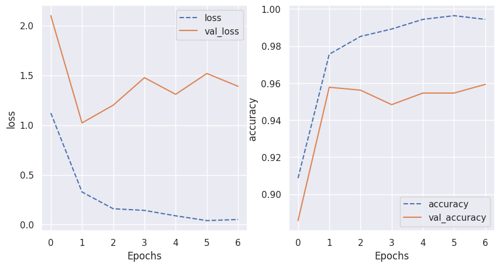

```
11/11 - 3s - 3s/epoch - 314ms/step
```

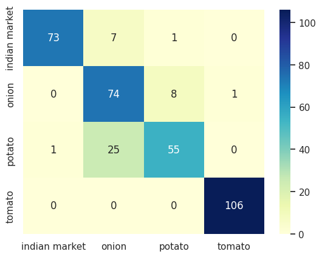

```
           class  precision  recall
0  indian market       0.99    0.90
1          onion       0.70    0.89
2         potato       0.86    0.68
3         tomato       0.99    1.00
Overall accuracy: 87.7%, macro precision: 0.88, macro recall: 0.87
```

```python
training_plot(['loss', 'accuracy'], model_history)
predict_and_plot_confusion_matrix(resnet_model_v1, test_ds1, classes)
```

**Observations:**

### Resnet V2

```python
model_name = 'resnet_v2'

optimizer = keras.optimizers.Adam(learning_rate=0.001)

resnet_model_v2, model_history = get_trained_model(

    model_name,

    # create_model_fn
    lambda model_name: tf.keras.Sequential(
      name=model_name,
      layers=[
          pretrained_resnet,
          tf.keras.layers.GlobalMaxPooling2D(),
          tf.keras.layers.Flatten(),
          tf.keras.layers.Dense(4, activation='softmax')]
      ),

    # compile_model_fn
    lambda model: get_compile_fn(model, optimizer=optimizer),

    # train_model_fn
    lambda model, train_data, val_data: model_fit_fn(model, train_data, val_data, epochs=10, callbacks=callbacks),

    #training data
    train_ds1,

    #validation data
    val_ds1,

    force_train = True
    )
```

[output not shown]

```
WARNING:absl:Found untraced functions such as _jit_compiled_convolution_op, _jit_compiled_convolution_op, _jit_compiled_convolution_op, _jit_compiled_convolution_op, _jit_compiled_convolution_op while saving (showing 5 of 53). These functions will not be directly callable after loading.
```

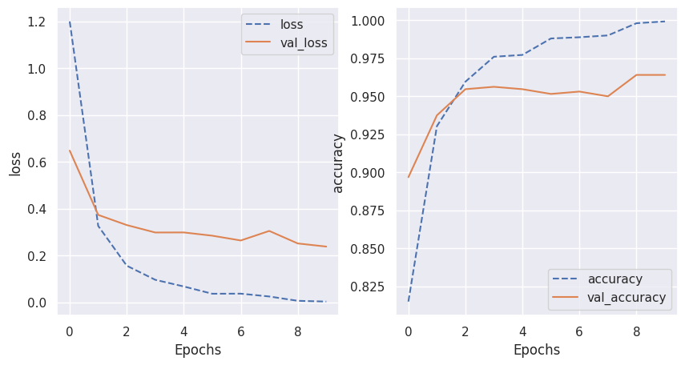

```
11/11 - 2s - 2s/epoch - 167ms/step
```

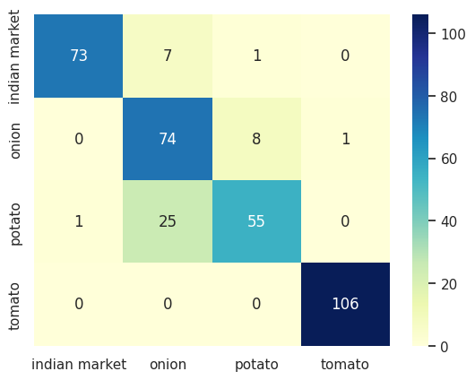

```
           class  precision  recall
0  indian market       0.99    0.90
1          onion       0.70    0.89
2         potato       0.86    0.68
3         tomato       0.99    1.00
Overall accuracy: 87.7%, macro precision: 0.88, macro recall: 0.87
```

```python
training_plot(['loss', 'accuracy'], model_history)
predict_and_plot_confusion_matrix(resnet_model_v1, test_ds1, classes)
```